# Divorce Prediction

Jan Maděra

- Source: https://www.kaggle.com/andrewmvd/divorce-prediction
- Prediction of divorce based on 54 answers to questionaire
- Dataset based on John Gottman's couples therapy questions. (https://cs.wikipedia.org/wiki/John_Gottman)
- 4 major emotional reactions that are destructive -> predictors of divorce.
- They are part of the Cascade Model of Relational Dissolution (They build upon each other):
  1. Criticism (attack on person's character or personality)
  2. Defensiveness (response to pathological criticism)
  3. Contempt (mentality of superiority)
  4. Stonewalling (mental and physical barriers to avoid interactions)

## Dataset

- 170 couples from Turkey
- 54 questions with 5 point scale response:
  - (0=Never, 1=Seldom, 2=Averagely, 3=Frequently, 4=Always)
- Divorce column (1=couple stayed together, 0=divorced)

|  | Q1 | Q2 | Q3 | Q4 | Q5 | Q6 | Q7 | Q8 | Q9 | Q10 | ... | Q46 | Q47 | Q48 | Q49 | Q50 | Q51 | Q52 | Q53 | Q54 | Divorce |
| --- | --- | --- | --- | --- | --- | --- | --- | --- | --- | --- | --- | --- | --- | --- | --- | --- | --- | --- | --- | --- | --- |
| 0 | 2 | 2 | 4 | 1 | 0 | 0 | 0 | 0 | 0 | 0 | ... | 2 | 1 | 3 | 3 | 3 | 2 | 3 | 2 | 1 | 1 |
| 1 | 4 | 4 | 4 | 4 | 4 | 0 | 0 | 4 | 4 | 4 | ... | 2 | 2 | 3 | 4 | 4 | 4 | 4 | 2 | 2 | 1 |
| 2 | 2 | 2 | 2 | 2 | 1 | 3 | 2 | 1 | 1 | 2 | ... | 3 | 2 | 3 | 1 | 1 | 1 | 2 | 2 | 2 | 1 |
| 3 | 3 | 2 | 3 | 2 | 3 | 3 | 3 | 3 | 3 | 3 | ... | 2 | 2 | 3 | 3 | 3 | 3 | 2 | 2 | 2 | 1 |
| 4 | 2 | 2 | 1 | 1 | 1 | 1 | 0 | 0 | 0 | 0 | ... | 2 | 1 | 2 | 3 | 2 | 2 | 2 | 1 | 0 | 1 |
| ... | ... | ... | ... | ... | ... | ... | ... | ... | ... | ... | ... | ... | ... | ... | ... | ... | ... | ... | ... | ... | ... |
| 165 | 0 | 0 | 0 | 0 | 0 | 0 | 0 | 0 | 0 | 0 | ... | 1 | 0 | 4 | 1 | 1 | 4 | 2 | 2 | 2 | 0 |
| 166 | 0 | 0 | 0 | 0 | 0 | 0 | 0 | 0 | 0 | 0 | ... | 4 | 1 | 2 | 2 | 2 | 2 | 3 | 2 | 2 | 0 |
| 167 | 1 | 1 | 0 | 0 | 0 | 0 | 0 | 0 | 0 | 1 | ... | 3 | 0 | 2 | 0 | 1 | 1 | 3 | 0 | 0 | 0 |
| 168 | 0 | 0 | 0 | 0 | 0 | 0 | 0 | 0 | 0 | 0 | ... | 3 | 3 | 2 | 2 | 3 | 2 | 4 | 3 | 1 | 0 |
| 169 | 0 | 0 | 0 | 0 | 0 | 0 | 0 | 1 | 0 | 0 | ... | 3 | 4 | 4 | 0 | 1 | 3 | 3 | 3 | 1 | 0 |

170 rows × 55 columns

```
Divorce values:
0    86
1    84
Name: Divorce, dtype: int64
```

- Data collected in Turkey -> cultural differences
- Selection bias: Either great marriage or complete disaster
- Marriage is only one type of relationship
  - Same conclusion cannot be generally applied on other kinds of relationships

## Dataset questions

```
0 :  If one of us apologizes when our discussion deteriorates, the discussion ends.

1 :  I know we can ignore our differences, even if things get hard sometimes.

2 :  When we need it, we can take our discussions with my spouse from the beginning and correct it.

3 :  When I discuss with my spouse, to contact him will eventually work.

4 :  The time I spent with my wife is special for us.

5 :  We don't have time at home as partners.

6 :  We are like two strangers who share the same environment at home rather than family.

7 :  I enjoy our holidays with my wife.

8 :  I enjoy traveling with my wife.

9 :  Most of our goals are common to my spouse.

10 :  I think that one day in the future, when I look back, I see that my spouse and I have been in harmony with each other.

11 :  My spouse and I have similar values in terms of personal freedom.

12 :  My spouse and I have similar sense of entertainment.

13 :  Most of our goals for people (children, friends, etc.) are the same.

14 :  Our dreams with my spouse are similar and harmonious.

15 :  We're compatible with my spouse about what love should be.

16 :  We share the same views about being happy in our life with my spouse

17 :  My spouse and I have similar ideas about how marriage should be

18 :  My spouse and I have similar ideas about how roles should be in marriage

19 :  My spouse and I have similar values in trust.

```

[output cut: 52 more lines]

```
46 :  When I discuss with my spouse, I stay silent because I am afraid of not being able to control my anger.

47 :  I feel right in our discussions.

48 :  I have nothing to do with what I've been accused of.

49 :  I'm not actually the one who's guilty about what I'm accused of.

50 :  I'm not the one who's wrong about problems at home.

51 :  I wouldn't hesitate to tell my spouse about her/his inadequacy.

52 :  When I discuss, I remind my spouse of her/his inadequacy.

53 :  I'm not afraid to tell my spouse about her/his incompetence.
```

### Correlation

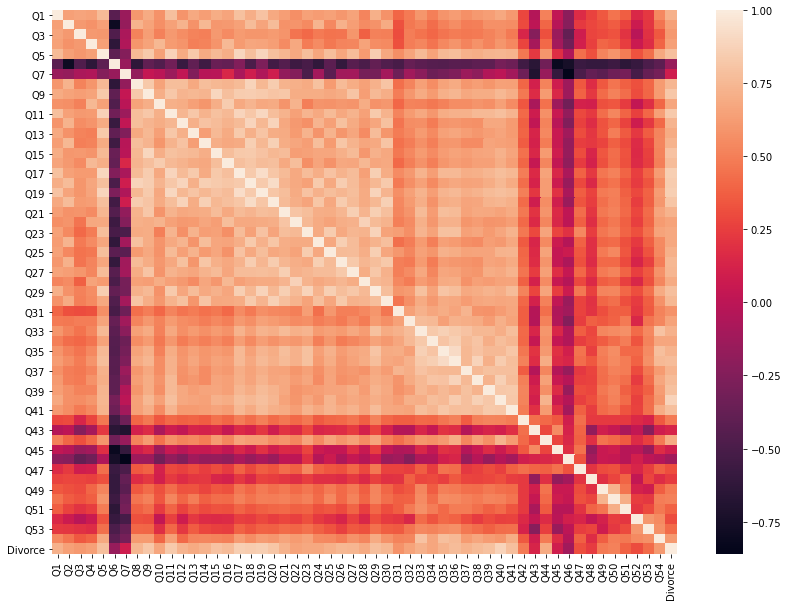